# Machine_Learing_Project_Coursera

Tim Norton

August 6, 2018

# Introduction

For this project, I am to determine the manner of how participants conducted exersize from data obtained by devices that track exercise. In the past, exersize has tracked the amount of exersize, but not how the exersize is done. This project is to find out if we can predict the manner in which the exersize is done from data gathered from these devices. The data is from sensors on people as they do exersize. Sometimes the participants do the exersize correctly and sometimes not. Finally, I predict the manner of exersize for previously unseen data. Below are dimensions of the dataset. As you can see, there are many features and many of them contain NAs. It was necessary to remove features with very little information in them. Also, many features described the subject who underwent the exersize leading to highly correlated attributes. It is unnecessary to use these attributes because they can be reduced to the one variable identifying the subject of the study. I split the data into a training and test set to perform predictions and assess the results.

```r
library(caret)
library(rattle)
library(plyr)
library(randomForest)
library(nnet)
library(AppliedPredictiveModeling)
library(e1071)
library(ElemStatLearn)
df<-read.csv(file="pml-training.csv", header=TRUE)
cat("Dimensions of entire training dataset: ",dim(df))
```

```
## Dimensions of entire training dataset:  19622 160
```

```r
train.dat <- which(colSums(is.na(df) |df=="")>0.9*dim(df)[1])
train.data <- df[,-train.dat]

train.data<-train.data[,-c(1:7)]
cat("Dimensions of cleaned training dataset: ",dim(train.data))
```

```
## Dimensions of cleaned training dataset:  19622 53
```

```r
set.seed(123)

inTrain = createDataPartition(train.data$classe, p = 3/4)[[1]]

training = train.data[ inTrain,]
dim(training)
```

```
## [1] 14718    53
```

```r
testing=train.data[-inTrain,]
dim(testing)
```

```
## [1] 4904   53
```

```r
x_train <- training[, -ncol(training)]
x_test <- testing[, -ncol(testing)]
y_train <- training$classe
y_test<-testing$classe
```

## Lasso Regression

Because there is a sparce dataframe of features, I chose lasso regression to proving a penalty to features that had little effect on the outome of a prediction. As you can see below, many features are zero. I set up the model to use the best parameters for prediction using the grid and trcontrol parameters, then display the coefficients used for the lasso regression. I used the model with the best lambda value, or size of the penalty that effects the number of features used in the model, and used five fold cross validation on the training set. Lasso regression is usually used for numerical classes, but I chose Lasso Regression to see how a linear model would perform on classification problems.

```r
control<-trainControl(method="cv", number=5, classProbs = TRUE)

tuneGrid=expand.grid(.alpha=1,.lambda=10^seq(10, -2, length = 100))

lasso.mod <- train(classe~.,data=training, method="glmnet",trControl=control, metric="Accuracy", tuneGrid=tuneGrid,  family="multinomial")

bestlam <- lasso.mod$lambda.min

lasso.pred <- predict(lasso.mod, s=bestlam, newdata =testing, type="raw")

lasso.con<-confusionMatrix( lasso.pred, testing$classe)

head(varImp(lasso.mod), 53)
```

```
## $importance
##                                 A          B           C          D
## roll_belt            0.000000e+00 0.00000000  0.00000000 0.37493523
## pitch_belt           0.000000e+00 0.00000000  0.00000000 0.00000000
## yaw_belt             0.000000e+00 0.00000000  0.00000000 0.00000000
## total_accel_belt     0.000000e+00 0.00000000  0.00000000 0.00000000
## gyros_belt_x         1.000000e+02 0.00000000  0.00000000 0.00000000
## gyros_belt_y         5.531670e+01 0.00000000  0.00000000 0.00000000
## gyros_belt_z         0.000000e+00 0.00000000 18.11713037 0.00000000
## accel_belt_x         0.000000e+00 0.00000000  0.00000000 0.00000000
## accel_belt_y         0.000000e+00 0.71465368  0.00000000 0.00000000
## accel_belt_z         4.869178e-01 0.00000000  0.00000000 0.00000000
## magnet_belt_x        1.095818e+00 0.00000000  0.00000000 0.00000000
## magnet_belt_y        0.000000e+00 0.00000000  0.00000000 1.21849220
## magnet_belt_z        5.092630e-01 0.00000000  0.00000000 0.00000000
## roll_arm             0.000000e+00 0.20640733  0.00000000 0.00000000
## pitch_arm            6.004254e-01 0.17778836  0.00000000 0.00000000
## yaw_arm              1.372930e-01 0.12450372  0.00000000 0.01880261
## total_accel_arm      0.000000e+00 0.00000000  0.00000000 0.00000000
## gyros_arm_x          0.000000e+00 0.00000000  0.00000000 0.00000000
## gyros_arm_y          4.329295e+00 0.00000000  0.00000000 0.00000000
## gyros_arm_z          0.000000e+00 0.00000000 16.60737140 0.00000000
## accel_arm_x          0.000000e+00 0.15985478  0.00000000 0.45821549
## accel_arm_y          0.000000e+00 0.00000000  0.00000000 0.00000000
## accel_arm_z          6.173637e-01 0.00000000  0.00000000 0.00000000
## magnet_arm_x         3.943701e-03 0.00000000  0.00000000 0.00000000
## magnet_arm_y         0.000000e+00 0.24704908  0.00000000 0.00000000
## magnet_arm_z         1.553366e-01 0.44046435  0.00000000 0.02970192
## roll_dumbbell        0.000000e+00 0.00000000  1.13946927 1.17853108
## pitch_dumbbell       0.000000e+00 0.00000000  0.31278419 0.00000000
## yaw_dumbbell         6.225701e-01 0.00000000  0.54257746 0.33655658
## total_accel_dumbbell 0.000000e+00 4.11087984  0.00000000 2.75798910
## gyros_dumbbell_x     0.000000e+00 0.00000000  0.00000000 0.00000000
## gyros_dumbbell_y     0.000000e+00 0.00000000  0.00000000 0.00000000
## gyros_dumbbell_z     0.000000e+00 0.00000000  0.00000000 0.00000000
## accel_dumbbell_x     0.000000e+00 1.77708447  0.00000000 0.00000000
## accel_dumbbell_y     0.000000e+00 0.29804218  0.47744523 0.00000000
## accel_dumbbell_z     4.679891e-02 0.01633127  0.00000000 0.00000000
## magnet_dumbbell_x    0.000000e+00 0.00000000  0.00000000 0.00000000
## magnet_dumbbell_y    0.000000e+00 0.11971844  0.00000000 0.00000000
```

[output cut: 58 more lines]

```
## gyros_forearm_x       0.00000000
## gyros_forearm_y       0.00000000
## gyros_forearm_z       0.00000000
## accel_forearm_x       0.00000000
## accel_forearm_y       0.00000000
## accel_forearm_z       0.54511833
## magnet_forearm_x      0.00000000
## magnet_forearm_y      0.05092659
## magnet_forearm_z      0.00000000
##
## $model
## [1] "glmnet"
##
## $calledFrom
## [1] "varImp"
```

## Principal Component Analysis

Because there are so many features, only a small subset of them could be used for predictions. If all of the features were used, there may be overfitting. Below is the investigation into principal components. When the pca parameter is used to fit the machine learning models below, I chose the number of principal components to equal a little less than %98 of the total variance. This turns out to be about 30 principal components instead of the 52 features contained in the dataset as you can see from the analysis below.

```r
pr_comp<-prcomp(x_train, scale=TRUE)

st_dev<-pr_comp$sdev

p_var<-st_dev^2

prop_ex<-p_var/sum(p_var)

summary(pr_comp)
```

```
## Importance of components:
##                           PC1   PC2     PC3    PC4     PC5     PC6     PC7
## Standard deviation     2.8940 2.839 2.15826 2.0712 1.92040 1.73879 1.49195
## Proportion of Variance 0.1611 0.155 0.08958 0.0825 0.07092 0.05814 0.04281
## Cumulative Proportion  0.1611 0.316 0.40560 0.4881 0.55902 0.61716 0.65997
##                            PC8     PC9    PC10    PC11    PC12    PC13
## Standard deviation     1.44674 1.31154 1.22948 1.17376 1.06498 0.99335
## Proportion of Variance 0.04025 0.03308 0.02907 0.02649 0.02181 0.01898
## Cumulative Proportion  0.70022 0.73330 0.76237 0.78886 0.81067 0.82965
##                          PC14    PC15    PC16    PC17    PC18    PC19
## Standard deviation     0.9429 0.90748 0.88704 0.82819 0.75526 0.72243
## Proportion of Variance 0.0171 0.01584 0.01513 0.01319 0.01097 0.01004
## Cumulative Proportion  0.8468 0.86258 0.87771 0.89090 0.90187 0.91191
##                           PC20    PC21    PC22    PC23    PC24    PC25
## Standard deviation     0.68825 0.64289 0.62711 0.60947 0.57735 0.54723
## Proportion of Variance 0.00911 0.00795 0.00756 0.00714 0.00641 0.00576
## Cumulative Proportion  0.92102 0.92897 0.93653 0.94368 0.95009 0.95584
##                           PC26    PC27    PC28    PC29    PC30    PC31
## Standard deviation     0.53362 0.50213 0.48136 0.44849 0.41347 0.39012
## Proportion of Variance 0.00548 0.00485 0.00446 0.00387 0.00329 0.00293
## Cumulative Proportion  0.96132 0.96617 0.97062 0.97449 0.97778 0.98071
##                           PC32    PC33    PC34    PC35    PC36    PC37
## Standard deviation     0.36248 0.34510 0.33401 0.30285 0.28111 0.25327
## Proportion of Variance 0.00253 0.00229 0.00215 0.00176 0.00152 0.00123
## Cumulative Proportion  0.98323 0.98552 0.98767 0.98943 0.99095 0.99219
##                           PC38    PC39    PC40    PC41    PC42   PC43
## Standard deviation     0.23593 0.23317 0.20002 0.19187 0.18478 0.1772
## Proportion of Variance 0.00107 0.00105 0.00077 0.00071 0.00066 0.0006
## Cumulative Proportion  0.99326 0.99430 0.99507 0.99578 0.99644 0.9970
##                           PC44    PC45    PC46    PC47    PC48    PC49
## Standard deviation     0.16770 0.16539 0.16313 0.14621 0.14204 0.11230
## Proportion of Variance 0.00054 0.00053 0.00051 0.00041 0.00039 0.00024
## Cumulative Proportion  0.99758 0.99811 0.99862 0.99903 0.99942 0.99966
##                           PC50    PC51    PC52
## Standard deviation     0.09834 0.07666 0.04577
## Proportion of Variance 0.00019 0.00011 0.00004
## Cumulative Proportion  0.99985 0.99996 1.00000
```

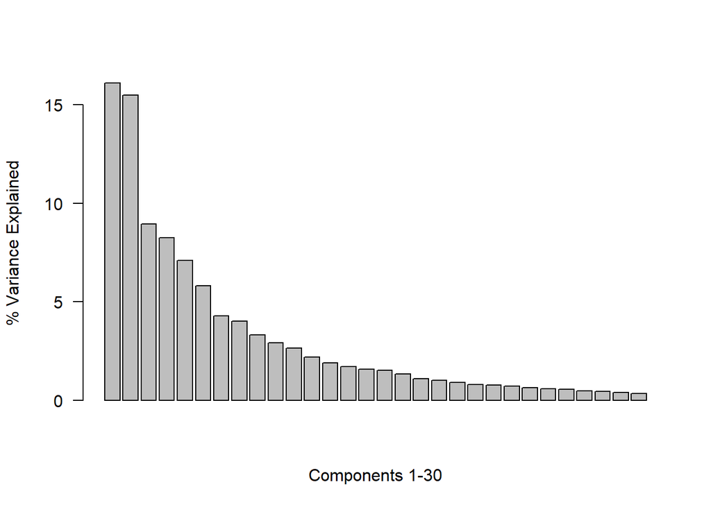

```r
barplot(100*prop_ex[1:30], las=2, xlab='Components 1-30', ylab='% Variance Explained')
```

# Training Models

## Fitting Support Vector Machines

```r
trcontrol<-trainControl(method="repeatedcv", number=5, repeats=3, classProbs=TRUE, summaryFunction=multiClassSummary)

svm.fit<-train(classe~., data=training, method="svmRadial", metric="Accuracy", preProcess = "pca", n.comp=30, trcontrol=trcontrol)
svm.pred<-predict(svm.fit, testing)
svm.con<-confusionMatrix(svm.pred, testing$classe)
```

## Fitting Random Forests

```r
trcontrol<-trainControl(method="repeatedcv", number=5, repeats=3, classProbs=TRUE, summaryFunction=multiClassSummary)

grid.tune<-expand.grid(.mtry=c(1:6))

rf_mod <- train(classe~.,data=training, method = "rf", metric="Accuracy", tuneGrid=grid.tune, preProcess = "pca", n.comp=30, trcontrol=trcontrol)
rf_pred<-predict(rf_mod, testing)
rf.con<-confusionMatrix(rf_pred, testing$classe)
```

## Fitting Neural Networks

```r
trcontrol<-trainControl(method="repeatedcv", number=5, repeats=3, classProbs=TRUE, summaryFunction=multiClassSummary)

grid <- expand.grid(.decay = c(.05, .01), .size = c(13,15,17))


nn.mod<-train(classe~., data=training, method="nnet", preProcess="pca", n.comp=30, maxit=1000, tuneGrid=grid, trcontrol=trcontrol)

nn.pred<-predict(nn.mod, testing, type="raw")
nn.con<-confusionMatrix(as.factor(nn.pred), testing$classe)
```

## Fitting Stacking Algorithm

```r
trcontrol<-trainControl(method="repeatedcv", number=5, repeats=3, classProbs=TRUE, summaryFunction=multiClassSummary)
predDF <- data.frame(svm.pred, rf_pred, nn.pred, classe=testing$classe)
modelStack <- train(classe ~ ., data = predDF, method = "gbm")
combPred <- predict(modelStack, predDF)
stack.con<-confusionMatrix(combPred, predDF$classe)
```

# Visualizations

Below are plots of some of the models above. They show that the Neural networks work best with an optimum level of decay of .05 and hidden units at 17.

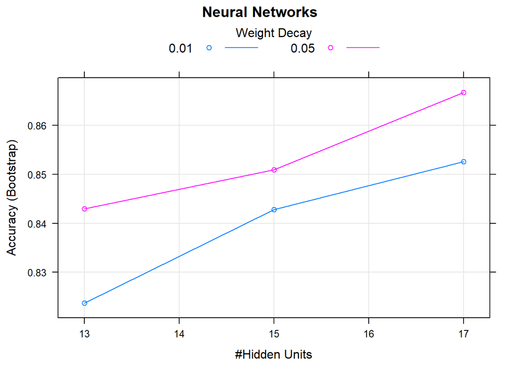

```r
plot(nn.mod, main="Neural Networks")
```

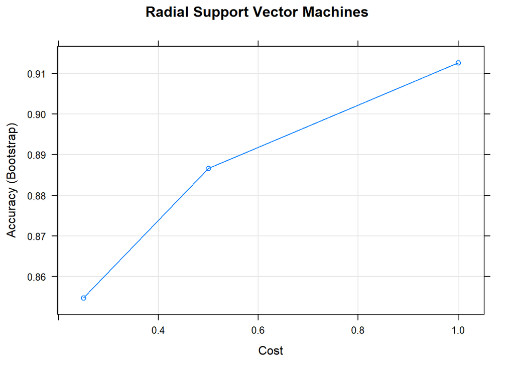

```r
plot(svm.fit, main="Radial Support Vector Machines")
```

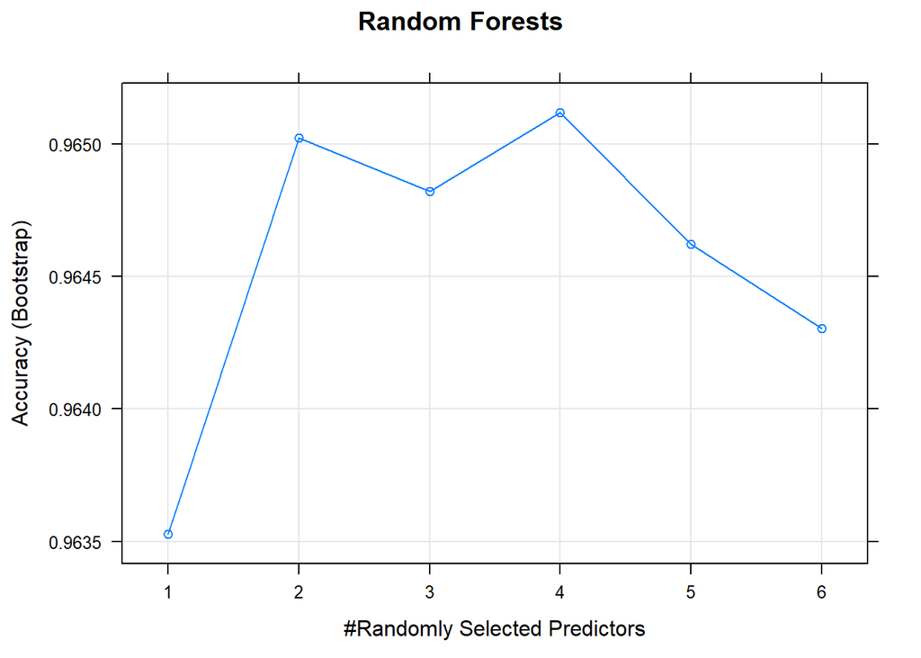

```r
plot(rf_mod, main="Random Forests")
```

The boosting algorithm used in stacking works best with fewer weak learners and smaller trees.

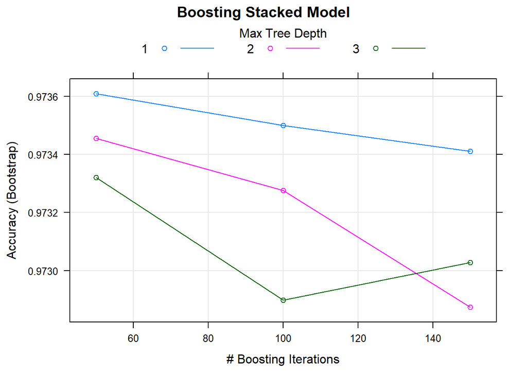

```r
plot(modelStack, main="Boosting Stacked Model")
```

# Accuracy

```r
cat("Lasso Regression Accuracy: ", lasso.con$overall[1])
```

```
## Lasso Regression Accuracy:  0.5921697
```

```r
cat("Suppor Vector Machine Accuracy: ", svm.con$overall[1])
```

```
## Suppor Vector Machine Accuracy:  0.9068108
```

```r
cat("Random Forest Accuracy: ", rf.con$overall[1])
```

```
## Random Forest Accuracy:  0.9743067
```

```r
cat("Neural Network Accuracy: ", nn.con$overall[1])
```

```
## Neural Network Accuracy:  0.8762235
```

```r
cat("Stached Algorithm Accuracy", stack.con$overall[1])
```

```
## Stached Algorithm Accuracy 0.9743067
```

# Prediction on Test Set

First, I load the test set into R and perform the same cleaning I performed for the training set.

```r
dat<-read.csv(file="pml-testing.csv", header=TRUE)


test.dats <- which(colSums(is.na(dat) |dat=="")>0.9*dim(dat)[1])

test.datas <- dat[,-test.dats]


test.datas<-test.datas[,-c(1:7)]
cat("Dimensions of Cleaned Test Set: ",dim(test.datas))
```

```
## Dimensions of Cleaned Test Set:  20 53
```

# Final Predictions and Conclusionn

```r
svm.test<-predict(svm.fit, newdata=test.datas)

rf.test<-predict(rf_mod, newdata=test.datas)

nn.test<-predict(nn.mod, newdata=test.datas)


pred.stack <- data.frame(svm.pred=svm.test, rf_pred=rf.test, nn.pred=nn.test)


com.predict <- predict(modelStack, pred.stack)


final.data<-cbind(pred.stack, com.predict)


names(final.data)<-c("svm", "RandomForest", "NeuralNetworks", "StackedAlgorithm")

final.data
```

```
##    svm RandomForest NeuralNetworks StackedAlgorithm
## 1    B            B              B                B
## 2    A            A              A                A
## 3    C            C              C                C
## 4    A            A              A                A
## 5    A            A              A                A
## 6    E            E              E                E
## 7    D            D              D                D
## 8    B            B              B                B
## 9    A            A              A                A
## 10   A            A              A                A
## 11   A            A              B                A
## 12   C            C              C                C
## 13   B            B              E                B
## 14   A            A              A                A
## 15   E            E              E                E
## 16   E            E              B                E
## 17   A            A              A                A
## 18   B            B              B                B
## 19   B            B              B                B
## 20   B            B              B                B
```